# Sparse Recovery with ℓ¹ Minimization

# Sparse Recovery with ℓ¹ Minimization

Investigate when a sparse vector can be recovered from fewer measurements than unknowns. Compare recovery outcomes across sparsity and sampling levels, and relate the experiments to the geometry of ℓ¹ minimization.

## Run this tour

Run the cells in order with a Python 3 kernel. The first cell locates the companion data and toolbox and installs missing dependencies when needed. All worked examples include their implementation directly in this notebook. Random seeds make comparisons reproducible; you can change them to explore other samples.

```python
# Locate the companion toolbox locally, or fetch it for a standalone/Colab copy.
from pathlib import Path
import importlib.util
import os
import subprocess
import sys

working = Path.cwd()
candidates = [working, working / "python", working.parent / "python"]
python_dir = next((p for p in candidates if (p / "nt_toolbox").is_dir()), None)
if python_dir is None:
    checkout = working / "numerical-tours-support"
    if not checkout.exists():
        subprocess.run(
            [
                "git",
                "clone",
                "--depth",
                "1",
                "--branch",
                "master",
                "https://github.com/gpeyre/numerical-tours.git",
                str(checkout),
            ],
            check=True,
        )
    python_dir = checkout / "python"
os.chdir(python_dir)
if str(python_dir) not in sys.path:
    sys.path.insert(0, str(python_dir))
requirements = python_dir / "requirements.txt"
if any(
    importlib.util.find_spec(name) is None
    for name in [
        "numpy",
        "scipy",
        "matplotlib",
        "skimage",
        "sklearn",
        "pywt",
        "ipywidgets",
        "cvxpy",
        "skfmm",
        "autograd",
        "progressbar",
        "celer",
    ]
):
    subprocess.run(
        [sys.executable, "-m", "pip", "install", "-r", str(requirements)], check=True
    )

import numpy as np
import matplotlib.pyplot as plt

np.random.seed(0)
plt.rcParams.update(
    {
        "figure.figsize": (8, 4),
        "figure.dpi": 100,
        "axes.spines.top": False,
        "axes.spines.right": False,
        "font.size": 11,
        "image.cmap": "gray",
    }
)
%matplotlib inline
```

$\newcommand{\dotp}[2]{\langle #1, #2 \rangle}$ $\newcommand{\enscond}[2]{\lbrace #1, #2 \rbrace}$ $\newcommand{\pd}[2]{ \frac{ \partial #1}{\partial #2} }$ $\newcommand{\umin}[1]{\underset{#1}{\min}\;}$ $\newcommand{\umax}[1]{\underset{#1}{\max}\;}$ $\newcommand{\uargmin}[1]{\underset{#1}{argmin}\;}$ $\newcommand{\norm}[1]{\|#1\|}$ $\newcommand{\abs}[1]{\left|#1\right|}$ $\newcommand{\choice}[1]{ \left\{ \begin{array}{l} #1 \end{array} \right. }$ $\newcommand{\pa}[1]{\left(#1\right)}$ $\newcommand{\diag}[1]{{diag}\left( #1 \right)}$ $\newcommand{\qandq}{\quad\text{and}\quad}$ $\newcommand{\qwhereq}{\quad\text{where}\quad}$ $\newcommand{\qifq}{ \quad \text{if} \quad }$ $\newcommand{\qarrq}{ \quad \Longrightarrow \quad }$ $\newcommand{\ZZ}{\mathbb{Z}}$ $\newcommand{\CC}{\mathbb{C}}$ $\newcommand{\RR}{\mathbb{R}}$ $\newcommand{\EE}{\mathbb{E}}$ $\newcommand{\Zz}{\mathcal{Z}}$ $\newcommand{\Ww}{\mathcal{W}}$ $\newcommand{\Vv}{\mathcal{V}}$ $\newcommand{\Nn}{\mathcal{N}}$ $\newcommand{\NN}{\mathcal{N}}$ $\newcommand{\Hh}{\mathcal{H}}$ $\newcommand{\Bb}{\mathcal{B}}$ $\newcommand{\Ee}{\mathcal{E}}$ $\newcommand{\Cc}{\mathcal{C}}$ $\newcommand{\Gg}{\mathcal{G}}$ $\newcommand{\Ss}{\mathcal{S}}$ $\newcommand{\Pp}{\mathcal{P}}$ $\newcommand{\Ff}{\mathcal{F}}$ $\newcommand{\Xx}{\mathcal{X}}$ $\newcommand{\Mm}{\mathcal{M}}$ $\newcommand{\Ii}{\mathcal{I}}$ $\newcommand{\Dd}{\mathcal{D}}$ $\newcommand{\Ll}{\mathcal{L}}$ $\newcommand{\Tt}{\mathcal{T}}$ $\newcommand{\si}{\sigma}$ $\newcommand{\al}{\alpha}$ $\newcommand{\la}{\lambda}$ $\newcommand{\ga}{\gamma}$ $\newcommand{\Ga}{\Gamma}$ $\newcommand{\La}{\Lambda}$ $\newcommand{\Si}{\Sigma}$ $\newcommand{\be}{\beta}$ $\newcommand{\de}{\delta}$ $\newcommand{\De}{\Delta}$ $\newcommand{\phi}{\varphi}$ $\newcommand{\th}{\theta}$ $\newcommand{\om}{\omega}$ $\newcommand{\Om}{\Omega}$

This tour explores theoretical garantees for the performance of recovery using $\ell^1$ minimization.

```python
import numpy as np
import scipy as scp
import pylab as pyl
import matplotlib.pyplot as plt

from nt_toolbox.general import np, plt, pylab
from nt_toolbox.signal import np, plt, pylab

import warnings

%matplotlib inline
```

## Sparse $\ell^1$ Recovery

We consider the inverse problem of estimating an unknown signal $x_0 \in \RR^N$ from noisy measurements $y=\Phi x_0 + w \in \RR^P$ where $\Phi \in \RR^{P \times N}$ is a measurement matrix with $P \leq N$, and $w$ is some noise.

This tour is focused on recovery using $\ell^1$ minimization $$ x^\star \in \uargmin{x \in \RR^N} \frac{1}{2}\norm{y-\Phi x}^2 + \la \norm{x}_1. $$

Where there is no noise, we consider the problem $ \Pp(y) $ $$ x^\star \in \uargmin{\Phi x = y} \norm{x}_1. $$

We are not concerned here about the actual way to solve this convex problem (see the other numerical tours on sparse regularization) but rather on the theoretical analysis of wether $x^\star$ is close to $x_0$.

More precisely, we consider the following three key properties

- *Noiseless identifiability*: $x_0$ is the unique solution of $ \Pp(y) $ for $y=\Phi x_0$.
- *Robustess to small noise*: one has $\norm{x^\star - x_0} = O(\norm{w})$ for $y=\Phi x_0+w$ if $\norm{w}$ is smaller than an arbitrary small constant that depends on $x_0$ if $\la$ is well chosen according to $\norm{w}$.
- *Robustess to bounded noise:* same as above, but $\norm{w}$ can be arbitrary.

Note that noise robustness implies identifiability, but the converse is not true in general.

## Coherence Criteria

The simplest criteria for identifiality are based on the coherence of the matrix $\Phi$ and depends only on the sparsity $\norm{x_0}_0$ of the original signal. This criteria is thus not very precise and gives very pessimistic bounds.

The coherence of the matrix $\Phi = ( \phi_i )_{i=1}^N \in \RR^{P \times N}$ with unit norm colum $\norm{\phi_i}=1$ is $$ \mu(\Phi) = \umax{i \neq j} \abs{\dotp{\phi_i}{\phi_j}}. $$

Compute the correlation matrix (remove the diagonal of 1's).

```python
remove_diag = lambda C: C - np.diag(np.diag(C))
Correlation = lambda Phi: remove_diag(abs(np.dot(np.transpose(Phi), Phi)))
```

Compute the coherence $\mu(\Phi)$.

```python
mu = lambda Phi: np.max(Correlation(Phi))
```

The condition $$ \norm{x_0}_0 < \frac{1}{2}\pa{1 + \frac{1}{\mu(\Phi)}} $$ implies that $x_0$ is identifiable, and also implies to robustess to small and bounded noise.

Equivalently, this condition can be written as $\text{Coh}(\norm{x_0}_0)<1$ where $$ \text{Coh}(k) = \frac{k \mu(\Phi)}{ 1 - (k-1)\mu(\Phi) } $$

```python
Coh = lambda Phi, k: (k * mu(Phi)) / (1 - (k - 1) * mu(Phi))
```

Generate a matrix with random unit columns in $\RR^P$.

```python
from numpy import random

normalize = lambda Phi: Phi / np.tile(np.sqrt(np.sum(Phi**2, 0)), (np.shape(Phi)[0], 1))
PhiRand = lambda P, N: normalize(random.randn(P, N))
Phi = PhiRand(250, 1000)
```

Compute the coherence and the maximum possible sparsity to ensure recovery using the coherence bound.

```python
c = mu(Phi)
print("Coherence:    %.2f" % c)
print("Sparsity max: %d" % np.floor(1 / 2 * (1 + 1 / c)))
```

```
Coherence:    0.30
Sparsity max: 2
```

**Worked example 1**

Display how the average coherence of a random matrix decays with the redundancy $\eta = P/N$ of the matrix $\Phi$. Can you derive an empirical law between $P$ and the maximal sparsity?

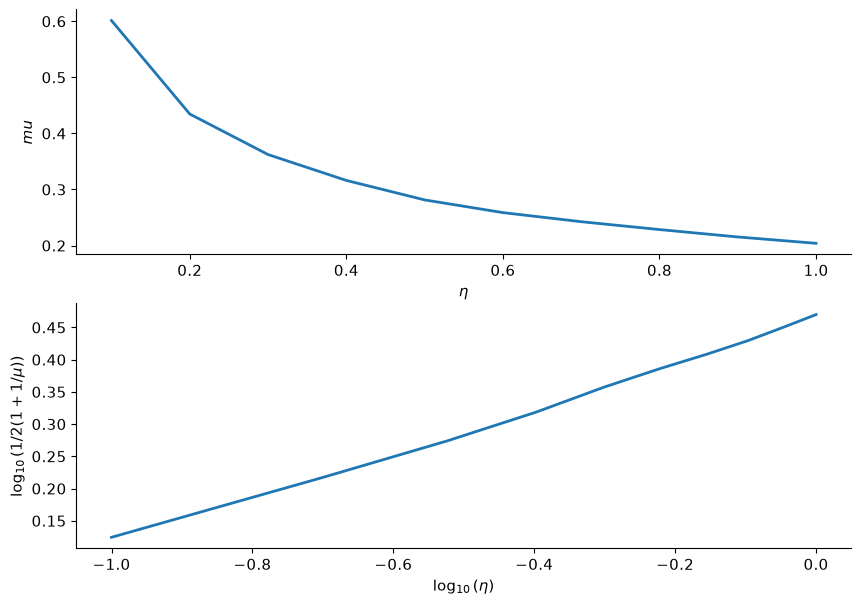

```python
eta_list = np.linspace(0.1, 1, 10)
ntrials = 20
mu_mean = []
mu_std = []
N = 500
for i in range(len(eta_list)):
    eta = eta_list[i]
    P = int(np.round(eta * N))
    c = []

    for k in range(ntrials):
        c = c + [mu(PhiRand(P, N))]

    mu_mean = mu_mean + [np.mean(c)]
    mu_std = mu_std + [np.std(c)]

k_mean = 1 / 2 * (1 + 1 / np.asarray(mu_mean))

plt.figure(figsize=(10, 7))

plt.subplot(2, 1, 1)
plt.plot(eta_list, mu_mean, linewidth=2)
plt.xlabel(r"$\eta$")
plt.ylabel("$mu$")

plt.subplot(2, 1, 2)
plt.plot(np.log10(eta_list), np.log10(k_mean), linewidth=2)
plt.xlabel(r"$\log_{10}(\eta)$")
plt.ylabel(r"$\log_{10}(1/ 2(1 + 1/ \mu))$")

plt.show()
```

## Support and Sign-based Criteria

In the following we will consider the support $$ \text{supp}(x_0) = \enscond{i}{x_0(i) \neq 0} $$ of the vector $x_0$. The co-support is its complementary $I^c$.

```python
supp = lambda s: np.where(abs(s) > 1e-5)[0]
cosupp = lambda s: np.where(abs(s) < 1e-5)[0]
```

Given some support $ I \subset \{0,\ldots,N-1\} $, we will denote as $ \Phi = (\phi_m)_{m \in I} \in \RR^{N \times \abs{I}}$ the sub-matrix extracted from $\Phi$ using the columns indexed by $I$.

J.J. Fuchs introduces a criteria $F$ for identifiability that depends on the sign of $x_0$.

J.J. Fuchs. *Recovery of exact sparse representations in the presence of bounded noise.* IEEE Trans. Inform. Theory, 51(10), p. 3601-3608, 2005

Under the condition that $\Phi_I$ has full rank, the $F$ measure of a sign vector $s \in \{+1,0,-1\}^N$ with $\text{supp}(s)=I$ reads $$ \text{F}(s) = \norm{ \Psi_I s_I }_\infty \qwhereq \Psi_I = \Phi_{I^c}^* \Phi_I^{+,*} $$ where $ A^+ = (A^* A)^{-1} A^* $ is the pseudo inverse of a matrix $A$.

The condition $$ \text{F}(\text{sign}(x_0))<1 $$ implies that $x_0$ is identifiable, and also implies to robustess to small noise. It does not however imply robustess to a bounded noise.

Compute $\Psi_I$ matrix.

```python
from numpy import linalg

PsiI = lambda Phi, I: np.dot(
    np.transpose(Phi[:, np.setdiff1d(np.arange(0, np.shape(Phi)[1]), I)]),
    np.transpose(linalg.pinv(Phi[:, I])),
)
```

Compute $\text{F}(s)$.

```python
F = lambda Phi, s: linalg.norm(np.dot(PsiI(Phi, supp(s)), s[supp(s)]), float("inf"))
```

The Exact Recovery Criterion (ERC) of a support $I$, introduced by Tropp in

J. A. Tropp. *Just relax: Convex programming methods for identifying sparse signals.* IEEE Trans. Inform. Theory, vol. 52, num. 3, pp. 1030-1051, Mar. 2006.

Under the condition that $\Phi_I$ has full rank, this condition reads $$ \text{ERC}(I) = \norm{\Psi_{I}}_{\infty,\infty} = \umax{j \in I^c} \norm{ \Phi_I^+ \phi_j }_1. $$ where $\norm{A}_{\infty,\infty}$ is the $\ell^\infty-\ell^\infty$ operator norm of a matrix $A$.

```python
erc = lambda Phi, I: linalg.norm(PsiI(Phi, I), float("inf"))
```

The condition $$ \text{ERC}(\text{supp}(x_0))<1 $$ implies that $x_0$ is identifiable, and also implies to robustess to small and bounded noise.

One can prove that the ERC is the maximum of the F criterion for all signs of the given support $$ \text{ERC}(I) = \umax{ s, \text{supp}(s) \subset I } \text{F}(s). $$

The weak-ERC is an approximation of the ERC using only the correlation matrix $$ \text{w-ERC}(I) = \frac{ \umax{j \in I^c} \sum_{i \in I} \abs{\dotp{\phi_i}{\phi_j}} }{ 1-\umax{j \in I} \sum_{i \neq j \in I} \abs{\dotp{\phi_i}{\phi_j}} }$$

```python
g = lambda C, I: np.sum(C[:, I], 1)
werc_g = lambda g, I, J: np.max(g[J]) / (1 - np.max(g[I]))
werc = lambda Phi, I: werc_g(
    g(Correlation(Phi), I), I, np.setdiff1d(np.arange(0, np.shape(Phi)[1]), I)
)
```

One has, if $\text{w-ERC}(I)>0$, for $ I = \text{supp}(s) $, $$ \text{F}(s) \leq \text{ERC}(I) \leq \text{w-ERC}(I) \leq \text{Coh}(\abs{I}). $$

This shows in particular that the condition $$ \text{w-ERC}(\text{supp}(x_0))<1 $$ implies identifiability and robustess to small and bounded noise.

**Worked example 2**

Show that this inequality holds on a given matrix. What can you conclude about the sharpness of these criteria ?

```python
N = 2000
P = N - 10
Phi = PhiRand(P, N)
s = np.zeros(N)
s[:6] = 1
I = supp(s)
k = len(I)

print("N = %d, P = %d, |I| = %d" % (N, P, k))
print("F(s)     = %.2f" % F(Phi, s))
print("ERC(I)   = %.2f" % erc(Phi, I))
print("w-ERC(s) = %.2f" % werc(Phi, I))
print("Coh(|s|) = %.2f" % Coh(Phi, k))
```

```
N = 2000, P = 1990, |I| = 6
F(s)     = 0.21
ERC(I)   = 0.22
w-ERC(s) = 0.26
Coh(|s|) = 1.60
```

```python
N = 2000
P = N - 10
Phi = PhiRand(P, N)
s = np.zeros(N)
s[:6] = 1
I = supp(s)
k = len(I)

print("N = %d, P = %d, |I| = %d" % (N, P, k))
print("F(s)     = %.2f" % F(Phi, s))
print("ERC(I)   = %.2f" % erc(Phi, I))
print("w-ERC(s) = %.2f" % werc(Phi, I))
print("Coh(|s|) = %.2f" % Coh(Phi, k))
```

```
N = 2000, P = 1990, |I| = 6
F(s)     = 0.23
ERC(I)   = 0.27
w-ERC(s) = 0.29
Coh(|s|) = 1.78
```

**Worked example 3**

For a given matrix $\Phi$ generated using PhiRand, draw as a function of the sparsity $k$ the probability that a random sign vector $s$ of sparsity $\norm{s}_0=k$ satisfies the conditions $\text{F}(x_0)<1$, $\text{ERC}(x_0)<1$ and $\text{w-ERC}(x_0)<1$

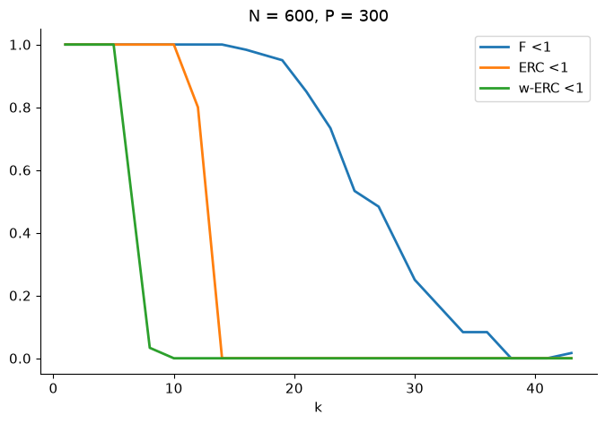

```python
N = 600
P = N // 2
Phi = PhiRand(P, N)
klist = np.round(np.linspace(1, P / 7.0, 20))
ntrials = 60
proba = np.zeros([len(klist), 3])

for i in range(len(klist)):
    proba[i, :3] = 0
    k = int(klist[i])
    for j in range(ntrials):
        s = np.zeros(N)
        I = random.permutation(N)
        I = I[:k]
        s[I] = np.sign(random.randn(k))
        proba[i, 0] = proba[i, 0] + (F(Phi, s) < 1)
        proba[i, 1] = proba[i, 1] + (erc(Phi, I) < 1)
        proba[i, 2] = proba[i, 2] + (werc(Phi, I) > 0) * (werc(Phi, I) < 1)

plt.figure(figsize=(8, 5))
plt.plot(klist, proba / ntrials, linewidth=2)
plt.xlabel("k")
plt.legend(["F <1", "ERC <1", "w-ERC <1"])
plt.title("N = %d, P = %d" % (N, P))
plt.show()
```

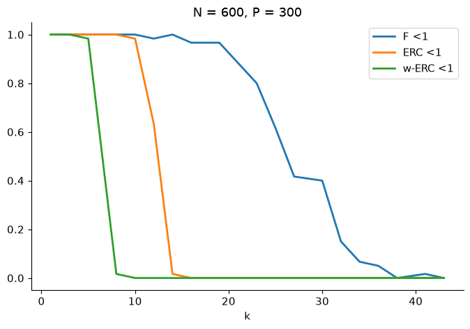

```python
N = 600
P = N // 2
Phi = PhiRand(P, N)
klist = np.round(np.linspace(1, P / 7.0, 20))
ntrials = 60
proba = np.zeros([len(klist), 3])

for i in range(len(klist)):
    proba[i, :3] = 0
    k = int(klist[i])
    for j in range(ntrials):
        s = np.zeros(N)
        I = random.permutation(N)
        I = I[:k]
        s[I] = np.sign(random.randn(k))
        proba[i, 0] = proba[i, 0] + (F(Phi, s) < 1)
        proba[i, 1] = proba[i, 1] + (erc(Phi, I) < 1)
        proba[i, 2] = proba[i, 2] + (werc(Phi, I) > 0) * (werc(Phi, I) < 1)

plt.figure(figsize=(8, 5))
plt.plot(klist, proba / ntrials, linewidth=2)
plt.xlabel("k")
plt.legend(["F <1", "ERC <1", "w-ERC <1"])
plt.title("N = %d, P = %d" % (N, P))
plt.show()
```

## Restricted Isometry Criteria

The restricted isometry constants $\de_k^1,\de_k^2$ of a matrix $\Phi$ are the smallest $\de^1,\de^2$ that satisfy $$ \forall x \in \RR^N, \quad \norm{x}_0 \leq k \qarrq (1-\de^1)\norm{x}^2 \leq \norm{\Phi x}^2 \leq (1+\de^2)\norm{x}^2. $$

E. Candes shows in

E. J. Cand s. *The restricted isometry property and its implications for compressed sensing*. Compte Rendus de l'Academie des Sciences, Paris, Serie I, 346 589-592

that if $$ \de_{2k} \leq \sqrt{2}-1 ,$$ then $\norm{x_0} \leq k$ implies identifiability as well as robustness to small and bounded noise.

The stability constant $\la^1(A), \la^2(A)$ of a matrix $A = \Phi_I$ extracted from $\Phi$ is the smallest $\tilde \la_1,\tilde \la_2$ such that $$ \forall \al \in \RR^{\abs{I}}, \quad (1-\tilde\la_1)\norm{\al}^2 \leq \norm{A \al}^2 \leq (1+\tilde \la_2)\norm{\al}^2. $$

These constants $\la^1(A), \la^2(A)$ are easily computed from the largest and smallest eigenvalues of $A^* A \in \RR^{\abs{I} \times \abs{I}}$

```python
minmax = lambda v: (1 - np.min(v), max(v) - 1)
ric = lambda A: minmax(linalg.eigvalsh(np.dot(np.transpose(A), A)))
```

The restricted isometry constant of $\Phi$ are computed as the largest stability constants of extracted matrices $$ \de^\ell_k = \umax{ \abs{I}=k } \la^\ell( \Phi_I ). $$

The eigenvalues of $\Phi$ are essentially contained in the interval $ [a,b] $ where $a=(1-\sqrt{\be})^2$ and $b=(1+\sqrt{\be})^2$ with $\beta = k/P$ More precisely, as $k=\be P$ tends to infinity, the distribution of the eigenvalues tends to the Marcenko-Pastur law $ f_\be(\la) = \frac{1}{2\pi \be \la}\sqrt{ (\la-b)^+ (a-\la)^+ }. $

**Worked example 4**

Display, for an increasing value of $k$ the histogram of repartition of the eigenvalues $A^* A$ where $A$ is a Gaussian matrix of size $(P,k)$ and variance $1/P$. For this, accumulate the eigenvalues for many realizations of $A$.

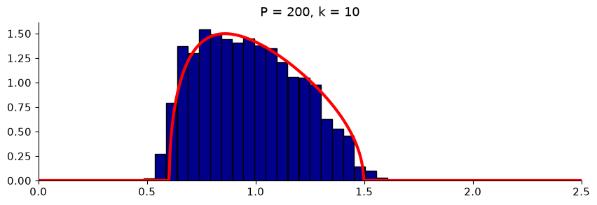

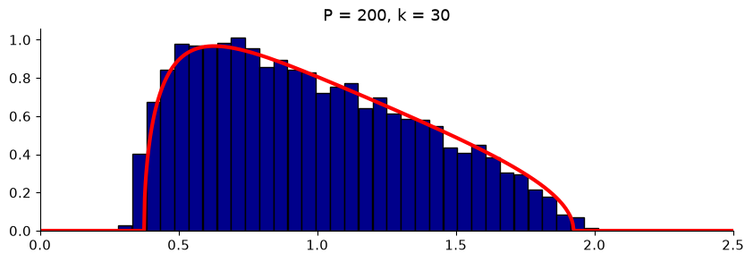

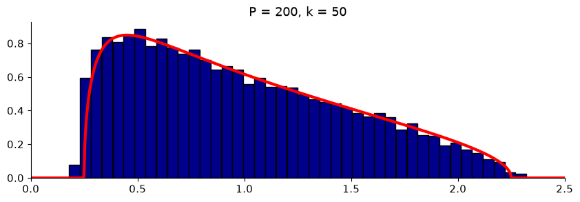

```python
klist = [10, 30, 50]
P = 200
ntrials = 200
tmin = 0
tmax = 2.5
q = 50
t = np.linspace(tmin, tmax, q)
t1 = np.linspace(max(tmin, 1e-8), tmax, 1000)
dt = (tmax - tmin) / q

for j in range(len(klist)):
    k = klist[j]

    # simulation
    v = []
    for i in range(ntrials):
        v = v + [linalg.svd(random.randn(P, k) / np.sqrt(P))[1] ** 2]

    plt.figure(figsize=(10, 10))
    plt.subplot(len(klist), 1, j + 1)
    h = np.histogram(v, t)[0]
    h = h / np.sum(h) / dt
    plt.bar(t[:-1], h, width=1 / 20, color="darkblue", edgecolor="black")

    # theoritical law
    beta = k / P
    a = (1 - np.sqrt(beta)) ** 2
    b = (1 + np.sqrt(beta)) ** 2
    z = np.sqrt(
        np.maximum(t1 - a, np.zeros(len(t1))) * np.maximum(b - t1, np.zeros(len(t1)))
    ) / (2 * np.pi * beta * t1)

    plt.plot(t1, z, "r", linewidth=3)
    plt.xlim(tmin, tmax)
    plt.ylim(0, max(h) * 1.05)
    plt.title("P = %d, k = %d" % (P, k))

    plt.show()
```

**Worked example 5**

Estimate numerically lower bound on $\de_k^1,\de_k^2$ by Monte-Carlo sampling of sub-matrices.

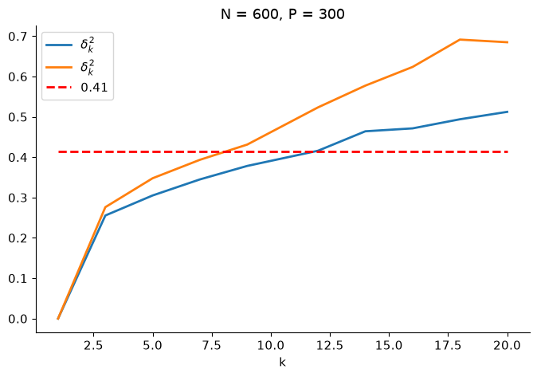

```python
N = 600
P = N // 2
Phi = PhiRand(P, N)
klist = np.round(np.linspace(1, P / 15.0, 10))
ntrials = 2000
rip_val = np.zeros([len(klist), 2])

for i in range(len(klist)):
    rip_val[i, :2] = 0
    k = int(klist[i])
    for j in range(ntrials):
        I = random.permutation(N)
        I = I[:k]
        a, b = ric(Phi[:, I])
        rip_val[i, :2] = np.maximum(rip_val[i, :2], [a, b])

plt.figure(figsize=(8, 5))

plt.plot(klist, rip_val, linewidth=2)
plt.plot(klist, klist * 0 + np.sqrt(2) - 1, "r--", linewidth=2)
plt.legend([r"$\delta^2_k$", r"$\delta^2_k$", "0.41"])
plt.xlabel("k")
plt.title("N = %d, P = %d" % (N, P))

plt.show()
```

## Sparse Spikes Deconvolution

Second derivative of Gaussian kernel $g$ with a given variance $\si^2$.

```python
sigma = 6
g = lambda x: (1 - x**2 / sigma**2) * np.exp(-(x**2) / (2 * sigma**2))
```

Create a matrix $\Phi$ so that $\Phi x = g \star x$ with periodic boundary conditions.

```python
P = 1024
[Y, X] = np.meshgrid(np.arange(0, P), np.arange(0, P))
Phi = normalize(g((X - Y + P / 2.0) % P - P / 2.0))
```

To improve the conditionning of the dictionary, we sub-sample its atoms, so that $ P = \eta N > N $.

```python
eta = 2
N = P // eta
Phi = Phi[:, ::eta]
```

Plot the correlation function associated to the filter. Can you determine the value of the coherence $\mu(\Phi)$?

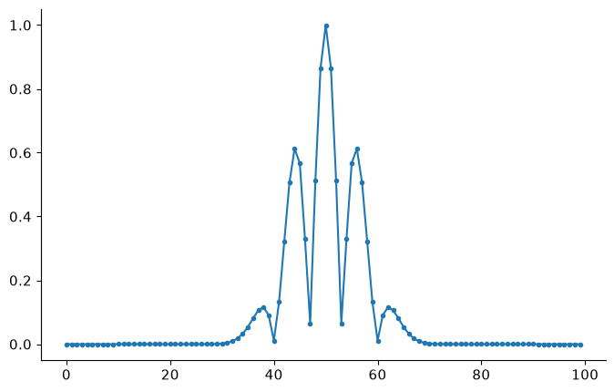

```python
c = np.dot(np.transpose(Phi), Phi)
c = np.abs(c[:, np.shape(c)[1] // 2])

plt.figure(figsize=(8, 5))
plt.plot(c[len(c) // 2 - 50 : len(c) // 2 + 50], ".-")
plt.show()
```

Create a data a sparse $x_0$ with two diracs of opposite signes with spacing $d$.

```python
twosparse = lambda d: np.roll(
    np.concatenate(([1.0], np.zeros(d), [-1.0], np.zeros(N - d - 2))),
    int(N / 2 - d / 2),
)
```

Display $x_0$ and $\Phi x_0$.

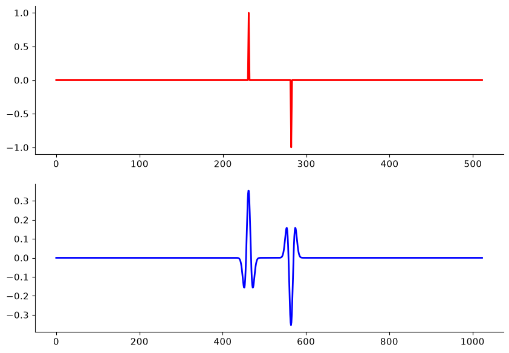

```python
x0 = twosparse(50)

plt.figure(figsize=(10, 7))
plt.subplot(2, 1, 1)
plt.plot(x0, "r", linewidth=2)
plt.subplot(2, 1, 2)
plt.plot(Phi @ x0, "b", linewidth=2)
plt.show()
```

**Worked example 6**

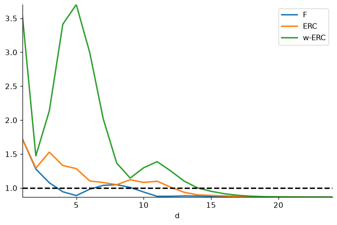

```python
g = lambda C, I: np.sum(C[:, I], 1)

plt.figure(figsize=(8, 5))
dlist = np.arange(1, N // 20, dtype=int)
criter = np.zeros([len(dlist), 3])

for i in range(len(dlist)):
    s = twosparse(dlist[i])
    I = supp(s)
    criter[i, :] = [F(Phi, s), erc(Phi, I), werc(Phi, I)]

criter[criter < 0] = float("inf")

plt.plot(dlist, criter, linewidth=2)
plt.plot(dlist, dlist * 0 + 1, "k--", linewidth=2)
plt.xlim(1, np.max(dlist))
plt.ylim(np.min(criter), np.max(criter))
plt.xlabel("d")
plt.legend(["F", "ERC", "w-ERC"])

plt.show()
```

## References and further reading

- David L. Donoho. [Compressed Sensing](https://doi.org/10.1109/TIT.2006.871582). 2006, IEEE Transactions on Information Theory 52(4), 1289–1306. Sparse recovery from undersampled linear measurements.
- Robert Tibshirani. [Regression Shrinkage and Selection via the Lasso](https://doi.org/10.1111/j.2517-6161.1996.tb02080.x). 1996, Journal of the Royal Statistical Society B 58(1), 267–288. Sparse regression through an absolute-value penalty.
- Neal Parikh and Stephen Boyd. [Proximal Algorithms](https://web.stanford.edu/~boyd/papers/prox_algs.html). 2014, Foundations and Trends in Optimization 1(3), 127–239. Proximity operators and splitting methods for nonsmooth objectives.
- Amir Beck and Marc Teboulle. [A Fast Iterative Shrinkage-Thresholding Algorithm for Linear Inverse Problems](https://doi.org/10.1137/080716542). 2009, SIAM Journal on Imaging Sciences 2(1), 183–202. Accelerated proximal gradient descent and its convergence rate.
- Stéphane Mallat. [A Wavelet Tour of Signal Processing: The Sparse Way](https://www.di.ens.fr/~mallat/biblio.html). 2009, 3rd ed., Academic Press. Multiresolution analysis, sparse approximation, and wavelet algorithms.